# Stock investors' reaction to layoff announcements: A meta‐analysis

Converted from PDF `Eshghi-LayoffInvestorReactionMetaAnalysis-2023-HRMJ.pdf` · 18 pages · anchors: page `#pN`, block `#pN-bK`

Page 1

*Hum Resour Manag J.* 2023;1–18. wileyonlinelibrary.com/journal/hrmj **1**

1Department, Faculty of Management, Laurentian University, Sudbury, Ontario, Canada

2Desautels Faculty of Management, McGill University, Montréal, Quebec, Canada

3Luddy School of Informatics, Computing, and Engineering, Indiana University Bloomington, Bloomington, Indiana, USA

#### **Correspondence**

Vivek Astvansh. Email: vivek.astvansh@mcgill.ca

[figure not shown]

NOTE: figure/graphic rendered as an image from the PDF; its content is not machine-readable text. Caption (if any) follows as the next block.

**text found inside the figure**

**Abstract**

Does a firm's layoff announcement elicit a negative or

a positive reaction from its stock investors? The extant

empirical evidence on this question is mixed. The authors'

meta-analysis of 34,594 layoff announcements taken from

126 samples featured in 78 studies reports that the aver-

age investor reaction is significantly negative (effect size of

−0.549). Next, the authors use signaling theory—specifically,

characteristics of the signal, the signaler, and the signaling

environment—to examine variation in investor reaction.

They find that investors do not react if a layoff announce-

ment signals proactive management (e.g., cost cutting) but

penalize the firm if the layoff indicates reactive management

(e.g., decline in demand). The penalty is also positively asso-

ciated with layoff size but unrelated to firm size. Further,

investors have become less punitive over time, or if its stock

consequences of their layoff announcements.

**K E Y W O R D S** downsizing, layoff, meta-analysis, stock return

#### **R E S E A R C H A R T I C L E**

## **Stock investors' reaction to layoff announcements: A meta-analysis**

### **Kamran Eshghi<sup>1</sup> | Vivek Astvansh<sup>2,3</sup>**

DOI: 10.1111/1748-8583.12532

Received: 8 February 2023 Revised: 6 July 2023 Accepted: 8 September 2023

### **1 | INTRODUCTION**

On 3 June 2022, Tesla announced cutting its salaried staff by 10%, citing inefficiency in terms of overstaffing as

the reason (Chokshi & Metz, 2022). By some estimates, the layoff news caused a 4% *drop* in Tesla's stock price

(Krantz, 2022). On 2 August 2022, Robinhood—the stock trading app—announced laying off 23% of its employees,

This is an open access article under the terms of the Creative Commons Attribution License, which permits use, distribution and reproduction in any medium, provided the original work is properly cited.

© 2023 The Authors. Human Resource Management Journal published by John Wiley & Sons Ltd.

Page 2

ESHGHI and ASTVANSH **2**

blaming inflation and the crash of the crypto market (Kelley & Yaffe-Bellany, 2022). Interestingly, investors inter-

preted this announcement favorably, and Robinhood's stock price *jumped* 15% a day after the announcement

(McCabe, 2022). These anecdotes suggest the curious case of stock investors reacting positively to some firm

announcements of employee layoffs but negatively to others.

Academics have measured the investor reaction to layoff announcements since 1990 (Abowd et al., 1990;

Blackwell et al., 1990; Worrell, Davidson III, & Sharma, 1991). Specifically, they have used the event study method to

measure the average value of the announcing firm's cumulative abnormal stock return (CAR) to the announcement/

event in a short window surrounding the date of an announcement. Interestingly, consistent with the two anecdotes

mentioned above, the empirical evidence is mixed. Whereas some studies have reported that—on average—investors

react positively (Brookman et al., 2007; Collett, 2002), reasoning that a firm's layoff announcement signals its top

management's attempt to cut unnecessary costs and unprofitable operations. In contrast, other academics have

documented a negative reaction (Filbeck & Webb, 2001; Hillier et al., 2007; Spivey et al., 1994), arguing that layoff

announcements signal overall poor performance by the top management. A third group of studies has found a statis-

tically insignificant reaction (Goins & Gruca, 2008; Scott et al., 2011), perhaps as a result of the two opposite signals

canceling out each other. What is thus needed is an empirical examination of *all* the “primary” studies to compute

average of the average reaction reported by individual studies and test whether this “meta-average” is statistically

greater than zero or less than zero. Therefore, our first research question is: *What is the average magnitude of investor*

*reaction to a firm's layoff announcement?*

The findings from the extant literature are mixed not only on the valence of investor reaction (i.e., whether posi-

tive or negative) but also on the magnitude of the reaction (Brauer & Zimmermann, 2019). Specifically, the literature

has recorded that investor reaction to layoff announcements varies from −5.077% (Kunert et al., 2017) to 2.09%

(Nzau, 2016). Motivated by this variation, our second research question is: *What explains the mixed findings from*

*extant research?*

Intuition suggests the effect size may vary by the characteristics of (1) the announcement, (2) announcing firm, (3)

the environment (e.g., sample period, country), and (4) methodological choices used by the primary studies. Because

a firm's layoff is costly to the firm, we view layoff announcement as the firm's signal to its investors. That is, invoking

signaling theory (Connelly et al., 2011; Spence, 1973), we create a conceptual framework to explore the heterogene-

ity by characteristics of (1) the signal (specifically, layoff type and layoff size), (2) the signaler characteristics (i.e., firm

size), and (3) the signaling environment (i.e., time, recession, and legal system).

We use the meta-analysis method to answer our two research questions (Duran et al., 2016; Garavan et al., 2021;

O'Boyle et al., 2016; Post & Byron, 2015). A meta-analysis quantitatively assimilates findings across periods, settings,

and methods (Hunter & Schmidt, 1991). Specifically, our meta-analysis uses 34,594 layoff announcements included

in 126 samples from 78 published and unpublished primary studies from multiple disciplines.

We report six key findings. First, on average, investors punish a firm that announces layoff; the average reaction

is −0.549%. Second, we classify the primary studies by whether the sampled layoff announcements signal (1) proac-

tive management of the firm's internal problem or external environmental challenges (hereafter, proactive layoff, for

brevity), (2) reactive management of such problems and challenges (i.e., reactive layoff), or (3) both. Our subsample

analysis reports that, on average, investors do *not* react to proactive layoffs, but penalize the firm for reactive layoffs.

These findings are consistent with the argument that managers use anticipatory impression management tactics to

suppress investor penalty. Third, layoff size makes the investor reaction more punitive, supporting the intuition that a

larger layoff means greater short-term loss to the firm. Fourth, contrary to our hypothesis, investor reaction does not

vary by size of the layoff-announcing firm. The theoretical insight is that the negative effect of firm size proffered by

logic of media attention cancels out with the positive effects suggested by agency theory and resource-based view

of the firm. Fifth, investors' negative reaction has decreased over the years, suggesting that investors have come to

expect layoffs. Sixth, consistent with what one would expect based on legal origin theory, investors in civil-law coun-

tries are more punitive than their counterparts in common-law countries.

Page 3

ESHGHI and ASTVANSH **3**

The substantive contribution of our research is to the literature on downsizing and layoffs in providing empirical

generalization about the investor reaction to layoff announcements. We help make sense of the disparate findings by

showing that—on average—investors react negatively to layoff announcements. Our most interesting and insightful

finding is that investors are punitive only when the layoff announcement signals reactive management of the firm's

internal problems or external environmental challenges. Alternatively stated, investor reaction is statistically insignif-

icant if the announcement conveys proactive management of the problems and challenges.

The impending economic recession in the world and the layoffs from technology companies worldwide make our

findings timely for managers, investors, and financial analysts. Specifically, the empirical generalization helps manag-

ers know that, on average, investors will penalize them for laying off employees. However, managers may frame the

layoff announcement such that it signals proactive management. Such anticipatory impression management may help

eschew investor penalty. Relatedly, our findings inform investors and financial analysts how the former react when

they receive news about corporate layoffs. Specifically, in showing that investors punish the firm only if the layoff

indicates reactive management, we show that investors are sophisticated and do not engage in a knee-jerk reaction.

Financial analysts can use the evidence to predict how the firm may perform in the future based on how investors

have reacted to its layoff announcements.

Our research makes two theoretical contributions. First, signals can be positive or negative (Connelly et al., 2011).

However, academics have—for the most part—applied signaling theory to positive signals of quality (Erdem et al., 2008;

Kirmani & Rao, 2000; Spence, 1973). In viewing a layoff announcement a firm's negative signal that it intentionally

sends to stakeholders, we enrich the signaling theory. Moreover, in considering heterogeneity explained by charac-

teristics of the signal, signaler, and signaling environment, we apply the theory in its whole rather than piecemeal.

Second, a signal can be managers' anticipated way of managing impressions. Building on this intuition, we integrate

signaling theory with anticipatory impression management to make sense of the novel finding that whereas reactive

layoffs receive investor penalty, their proactive counterparts avoid any type of reaction. This insight—built on an

integration of theories of signaling and impression management—is a novel way of looking at real-world phenomena.

We structure the rest of the manuscript as follows. The next section summarizes the tenets of signaling theory.

Subsequently, we present arguments in support of our hypotheses H1 through H6. We enrich these arguments by

borrowing rationale from complementary theoretical perspectives, such as those of impression management. The

next sections detail our method, analyses, results, and robustness checks. We conclude with a discussion of the

implications of our findings for theory and practice.

### **2 | SIGNALING THEORY**

A firm and its stakeholder groups are two agents involved in economic and social valuation of the firm. These stake-

holder groups (hereafter, stakeholders, for brevity) include investors, consumers, rivals/peers, employees, suppliers,

and the local community in which the firm operates. Unsurprisingly, the firm—or more exactly, its managers—know

more and better about the firm than the firm's stakeholders. On the one hand, stakeholders seek higher quantity and

quality of information about the firm. On the other hand, managers release information strategically to the stakehold-

ers. *Signaling theory* offers a way of understanding this information exchange.

A *signal* is a deliberate action by one party (the sender/signaler) to communicate its private information that a

counterpart (the receiver) values. The information can be about the party's quality,<sup>1</sup> intent, or both. The receiver

chooses how to interpret the signal. In sending the signal, the sender hopes that the receives would take an action

that benefits the sender, such as choosing the sender (as an employer, supplier, or investee) over alternatives

(Connelly et al., 2011).

Academics have proposed three models of signaling. First, Spence's (1973) model is the dominant paradigm of

signaling. Spence (1973) considered a signal to be *credible* only if it is costly. Two examples of Spence-style signals

are education (Spence, 1973) and advertising (Kirmani & Rao, 2000). Second is Lacker and Weinberg's (1989) *costly*

Page 4

ESHGHI and ASTVANSH **4**

*state falsification* model. The authors used the term “state” for the private information that an agent has and which

it releases to the public. The model requires that if the firm were to falsify its state, it must maintain two sets of

records: the true set and the false set. The resulting distortion is thus costly to the firm (called falsification cost). The

model also requires that the receiver can verify the information post hoc. The third model is Stocken's (2000) *cheap*

*talk,* which reasons that repeated interactions between a firm and its multiple stakeholders make a firm concerned

about its reputation and thus imprecise/cheap talk becomes credible and improves outcomes. This concern for cred-

ibility/reputation ensures that the firm almost always reveals its private information, provided (a) the interactions are

sufficiently repeated, (b) the firm is sufficiently patient, and (c) the revelation is sufficiently useful for assessing the

truthfulness.

Although a firm usually sends unambiguously positive signals to its stakeholders, it may occasionally send signals

that some stakeholders may perceive negatively. In their review of signaling theory, Connelly et al. (2011, p. 59) noted

that “there is little empirical study of such negative signals, how they are unique from other signals.” Employee layoff

announcements—the focus of our research—represent one such signal. Other examples include announcements of

product recall (e.g., Astvansh & Eshghi, 2023), employee-directed lapses (e.g., Groening, Mittal, & Zhang, 2016) and

seasoned equity offering (e.g., Karim et al., 2001).

Stakeholder response to a signal is influenced by characteristics of (1) the *signal*, (2) the *signaler*, and (3) the *signaling*

*environment*. Characteristics of the signal include its *credibility*, which suggests how reliable or trustworthy the signaled

information is (Saboo & Grewal, 2013). The greater the costs incurred by the signaler in providing the information, the

more credible the receiver interprets the signal to be. Credibility thus separates signal from noise. The other common

signal characteristic is the signal's *fit* with the receiver (Boyd et al., 2023), also known as *appropriateness* (Saboo &

Grewal, 2013) or *relevance* (Groening, Mittal, & Zhang, 2016) to the receiver. That is, fit refers to “the extent to which

the signal corresponds with the sought-after quality of the signaler” (Connelly et al., 2011, p. 52). Signaler characteristics

are firm-specific characteristics, such as age and size. Lastly, signaling environment refers to the business environment

in which the signal is released. Typical characteristics of the signaling environment include the number of similar signals

sent by the signaler or its peers in the recent past, the state of the economy, and the year the signaler sent the signal.

We view a firm's announcement of employee layoffs as a signal from the announcing firm to its stock investors.

We next examine the heterogeneity in the investor reaction by characteristics of the signal, the signaler, and the

signaling environment (Figure 1).

### **3 | HYPOTHESES**

### **3.1 | Investor reaction to layoff announcement as signal**

A firm's layoff announcement conveys to the firm's investors (and other stakeholders) information that is unobserva-

ble and thus valuable to them. In addition, a layoff announcement is costly to the firm (Brauer & Zimmermann, 2019).

Consequently, we view a firm's layoff announcement as the firm's *signal* to its investors (Filbeck & Webb, 2001; Ursel

& Armstrong-Stassen, 1995).

The literature has suggested five reasons why investors—on average—react negatively to a firm's announcement of

employee layoff. First, because a layoff-announcing firm likely makes severance payments to laid-off employees (Brauer

& Zimmermann, 2019) and/or negotiate/litigate with employee unions (Velásquez et al., 2018), a layoff hurts the firm's

cash flow in the immediate future (Cascio, 1993). Second, employees who survive the layoff may lack commitment toward

the firm or perform less well relative to the pre-layoff period (Paulsen et al., 2005; Van Dierendonck & Jacobs, 2012).

Layoff may thus lower employee satisfaction and morale (Harney et al., 2018), which may, in turn, hamper the firm's near-

term performance. Third, the firm loses the knowledge capital of the laid-off employees (Nixon et al., 2004). Such loss

may cause a decline in the firm's performance in knowledge-intensive areas, such as sales, research and development,

and innovation. Fourth, a layoff announcement jeopardizes customer trust, leading to lower satisfaction (Lewin, 2009)

Page 5

ESHGHI and ASTVANSH **5**

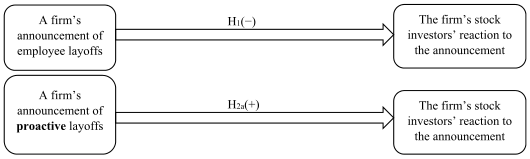

NOTE: figure/graphic rendered as an image from the PDF; its content is not machine-readable text. Caption (if any) follows as the next block.

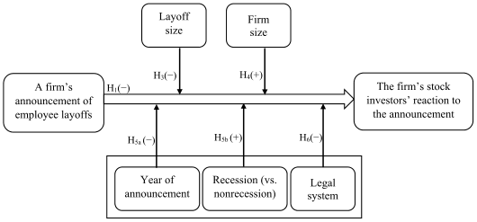

NOTE: figure/graphic rendered as an image from the PDF; its content is not machine-readable text. Caption (if any) follows as the next block.

and a loss of reputation (Flanagan & O’Shaughnessy, 2005; Landsman & Stremersch, 2020). Worse case, customers may

be less willing to support the firm (Landsman & Stremersch, 2020). Therefore, investors expect a loss of sales and, thus,

a lower level of cash flow in the future. Fifth, a layoff decision indicates the firm's low performance, financial trouble

(Bichescu & Raturi, 2015; Iqbal & Shetty, 1995; Lee, 1997), or unfavorable environmental changes such as a decline in

future demand (Cagle et al., 2009; McKnight et al., 2002). These five reasons lead us to the following hypothesis:

**Hypothesis (H1).** On average, a firm's layoff announcement elicits a negative reaction from its stock investors.

The magnitude of the firm's investors' punitive reaction to a layoff announcement may depend on the charac-

teristics of the *signal* (i.e., layoff type and layoff size), *signaler* (i.e., size of the layoff-announcing firm), and *signaling*

*environment* (e.g., time, state of economy, and the legal system) (Bhana, 2002; Lee, 1997; Nixon et al., 2004; Worrel

et al., 1991). We next offer our hypotheses on how these characteristics explain the heterogeneity in investor reac-

tion to layoff announcements.

### **3.2 | Signal characteristics**

### 3.2.1 | Layoff as proactive versus reactive management

A firm lays off employees for predominantly two reasons. Some layoffs are undertaken to restructure the firm. The

restructuring aims to boost the firm's efficiency and competitiveness (Chadwick et al., 2004; Worrel et al., 1991).

**F I G U R E 1** Conceptual framework.

Page 6

ESHGHI and ASTVANSH **6**

Conversely, a firm may lay off employees due to changes in the market, such as a fall in demand or internal financial

problems. Accordingly, some primary studies have classified a firm's layoff announcement as its *proactive* manage-

ment of its internal or environmental issues or the *reactive* management thereof, respectively (hereafter, “proactive

layoffs” and “reactive layoffs,” respectively, for brevity).

On the one hand, a proactive layoff signals that the firm has thought through the benefits and costs of layoff and

found the layoff decision optimal for future performance (Geoffrey Love & Nohria, 2005). Following this strategy, firms

usually lay off employees (1) to increase productivity and efficiency, (2) to restructure/reorganize themselves to boost

their competitiveness (Chen et al., 2001; Palmon et al., 1997), and/or (3) to expedite decision-making and communica-

tion (Brauer & Zimmermann, 2019). Should these reasons underlie the firm's layoffs, its investors may view these layoffs

as enhancing future cash flow and thus reward the firm (Blackwell et al., 1990; Elayan et al., 1998; Lin & Rozeff, 1993).

On the other hand, a reactive layoff signals that the firm has not well managed the situation and is now catch-

ing up (Geoffrey Love & Nohria, 2005). The investors would interpret a reactive layoff as substantial damage to the

firm's expected cash flow in the future. They would, thus, penalize the firm by driving down its stock price (Elayan

et al., 1998; Gunderson et al., 1997; Lee, 1997; Schweizer & Bilsdorfer, 2016).

Besides signaling theory, impression management theory makes the same prediction (Graffin et al., 2016; Lee, 1997).

As a rational entity, a firm tries to provide sufficient and logical reasons for its managerial decisions, aiming to manage

favorably its impressions on its investors. Managers of a layoff-announcing firm know that a proactive framing of a layoff

may suppress investor penalty, or—in the best case—earn a reward from investors. They also know that a reactive fram-

ing may receive a stronger penalty and may damage their own compensation and future career prospects. Therefore, to

the extent that managers avail of anticipatory impression management, and such management is effective, investors will

react positively to proactive layoff announcements but negatively to their reactive counterparts. Therefore, we propose:

**Hypothesis (H2a).** A firm's proactive layoff announcement elicits a positive reaction from its stock investors.

**Hypothesis (H2b).** A firm's reactive layoff announcement elicits a negative reaction from its stock investors.

### 3.2.2 | Layoff size

The literature suggests three reasons why layoff size amplifies the negative reaction—on average—from investors

of the layoff announcing firm. First, a large-scale (vs. small-scale) downsizing causes a greater loss in knowledge

capital (Nixon et al., 2004). Second, a large (vs. small) layoff could result in more damage to internal routines and

networks. Indeed, by virtue of removing a large number of employees who serve as nodes in the firm's network and

organizational structure, a large (vs. small) layoff causes a greater omission and disruption in the firm's knowledge

network and routines (Brauer & Laamanen, 2014). Third, large-scale downsizing amplifies negative survivor effects,

and potential turnover rates (Krishnan et al., 2007), leading to greater loss in knowledge capital and structure. Overall,

the magnitude of layoff signals the severity of firm's problems (Lee, 1997). The larger the magnitude of the layoff, the

greater the direct and indirect costs of layoff such as severance payment and turnover rate. Therefore, we propose:

**Hypothesis (H3).** The size of a firm's layoff exacerbates the negative reaction from its stock investors.

### **3.3 | Signaler characteristic**

### 3.3.1 | Firm size

Firm size proxies information asymmetry between the firm's managers and its investors. That is, the larger the firm, the

less well-informed the investors. Primary studies have reported mixed findings on the effect of a layoff-announcing

Page 7

ESHGHI and ASTVANSH **7**

firm's size on its investors' reaction. Some studies have reported a statistically insignificant relation (e.g., Brauer &

Zimmermann, 2019; Chalos & Chen, 2002), whereas others have confirmed that a larger firm receives lower penalty

than its smaller counterpart (e.g., Fama & French, 1992; Schulz & Himme, 2022). We draw upon the theoretical lenses

used by these primary studies to establish our hypothesis.

The agenda setting theory of mass media (McCombs & Shaw, 1972) and the concomitant logic of media repu-

tation (Deephouse, 2000) suggest that, on average, larger firms receive more media attention than their smaller

counterparts. This attention amplifies in the context of negative news that are relevant to society, such as employee

layoffs (Filbeck & Webb, 2001). Because the stock price of a larger (vs. smaller) firm is more volatile, a larger firm may

receive stronger investor reaction than its smaller counterpart.

Interestingly, agency theory (Jensen & Meckling, 1976) and resource-based view of the firm (Wernerfelt, 1984)

suggest the opposite—that is, the larger a layoff-announcing firm, the lower penalty it receives from its investors.

Specifically, these theories offer three reasons why firm size suppresses investor penalty. First, agency theory posits

that managers in large (vs. small) firms have lower incentives to downsize due to pecuniary and nonpecuniary benefits

that they gain from managing a “large” firm (Datta et al., 2010). Therefore, when larger firms decide to downsize, the

shareholders would view it as an efficiency-enhancing decision and react less negatively toward it. Second, because

a larger firm has superior access to capital markets, diverse sources of income, and lower costs for capital, it absorbs

negative financial shocks better than a smaller firm (Hendricks & Singhal, 2005). As such, following a layoff announce-

ment, the changes in cash flow of a large firm tend to be smaller, and the deceleration in cash flow is less steep

compared to a smaller firm. The smaller the negative impact on future cash flow of a firm, the smaller the negative

reaction from its investors.

On average, we reason that the logics of agency theory and resource-based view of the firm will override the

rationale of the media reputation. Therefore:

**Hypothesis H4.** The size of a layoff-announcing firm suppresses the negative reaction from stock investors.

### **3.4 | Signaling environment**

### 3.4.1 | Time and recession

On the one hand, research on human resources management (HRM) practices *during recession* has attracted little

attention from HRM academics (Johnstone, 2023). On the other hand, the literature on the stock investors' reaction

to layoff announcements has emphasized the importance of considering the year of layoff when assessing investor

reaction (Farber & Hallock, 2009; Marshall et al., 2012). Interestingly, the evidence from these studies is mixed. For

instance, Abowd et al. (1990) found an insignificant investor reaction to layoffs announced between 1980 and 1987.

Chatrath et al. (1995) reported insignificant reactions to layoffs announced during the 1981–1983 and 1984–1990

periods but positive reactions to announcements during 1991–1992.

Aiming to explain these mixed findings, a few studies have suggested that investor reaction varies by the

year of announcement. However, the results are inconclusive for these studies as well. Specifically, Farber and

Hallock (2009) and Farber and Hallock (1999) suggested that investors react less harshly to more recent layoffs.

However, McKnight et al. (2002) reached the opposite conclusion. Blanchard's (1981) model showed that, in equi-

librium, the same news can sometimes help the firm's financial performance and hurt it at other times. More impor-

tantly, the *state of the economy* determines whether the effect is helpful or hurtful. Relatedly, some studies on layoff

announcements and investor reactions have connected the period to the economic situation. During recession, firms

are often under duress to cut costs such as labor costs (Zeitoun & Pamini, 2021). Investors may react *less* severely

to a layoff during difficult economic times (e.g., recession) relative to their reaction to a layoff in business-as-usual

circumstances (Brauer & Zimmermann, 2019). Following Boyd et al. (2005), we propose that the investor reaction to

Page 8

ESHGHI and ASTVANSH **8**

layoff announcements depends on the state of the economy. Specifically, we hypothesize that investors' reaction to

a layoff is less punitive in more recent (vs. distant) times and during economically challenging (vs. business-as-usual

times).

**Hypothesis (H5a).** The negative reaction from stock investors of a layoff announcing firm is larger for less recent

layoffs when compared to more recent layoffs.

**Hypothesis (H5b).** The negative reaction from stock investors of layoff announcing firm is smaller during years of

recession compared to those of nonrecession.

### 3.4.2 | Legal system

The legal origin theory (La Porta et al., 1999) classifies countries based on whether they follow common law or civil

law. Countries such as the United Kingdom, United States, Canada, and other English-speaking ones follow common-

law systems, which place a strong emphasis on case law. Conversely, countries such as France, Germany, and Japan

follow civil law, which is characterized by codified law. Case law refers to the body of legal principles and rules that

are based on judgments on precedent or prior cases. In contrast, codified law follows legal codes and statutes that are

enacted by legislative bodies, such as the U.S. Congresses (Von Mehren, 1997). This difference means that whereas

case-law judicial system relies on judges' subjective interpretation, codified law relies more on objectivity.

These legal systems have impacted the economic development of countries and firms that operate in these coun-

tries. Because variation in legal systems translates into heterogeneity in legal and regulatory environments, investors

in these two groups of countries may react differently to similar events (Banker et al., 2013; Gerlach et al., 2006).

Therefore, comparing the reactions to announcements by firms in common law countries and those by firms traded

in civil law countries can be insightful.

We suggest two reasons why stock investors in common-law countries are less punitive than their civil-law coun-

terparts toward announcements of layoffs.

First, financial markets (e.g., New York Stock Exchange or London Stock Exchange) are more developed and

mature in common-law countries. Such development and maturity translate into stronger investor protection and

financial-law enforcement (Atanassov & Kim, 2009; La Porta et al., 2000). Regulatory bodies, such as the U.S. Secu-

rities and Exchange Commission or the U.K.‘s Financial Conduct Authority, administer and control stock market

activities.

Second, HRM practices and employee/labor unionization vary across countries (Goergen et al., 2013; Moy &

Sorrentino, 1981). Civil-law countries have adopted more comprehensive labor laws that codify labor rights and

procedures, providing a more structured legal framework for unions (Snikersproge, 2023). In contrast, in common-law

countries—where labor laws related to unions are usually based on case law—courts play a crucial role in interpreting

the labor law. In fact, employer rights are weaker, while employee rights are stronger in civil-law countries, and the

opposite is true in common-law countries (La Porta et al., 2000). Therefore, firms located in common-law countries

(vs. those in civil-law countries) should have fewer impediments to lay off employees. Moreover, the role of unions

has strengthened in civil-law countries compared to common-law countries in the past few decades (Atanassov &

Kim, 2009). For example, in the 1950s, a third of U.S. workers were members of employee/labor unions. In 2022,

this number reduced to about 10%.<sup>2</sup> Civil-law countries have a higher level of union coverage than countries with

common law, such as the United States. For example, more than 75% of workers in Denmark, Sweden, and Finland

are members of labor unions.<sup>3</sup> Consequently, layoffs are less costly in common-law countries than in civil-law coun-

tries (La Porta et al., 2000).

When weak investor protection intertwines with strong union laws—which is more common in civil-law

countries—we expect that common-law financial markets (e.g., United States) react to a layoff-announcing firm less

punitively than their civil-law counterparts (i.e., mostly European and Asian).

Page 9

ESHGHI and ASTVANSH **9**

**Hypothesis (H6).** The negative reaction from stock investors of a layoff-announcing firm is larger for firms whose

stock is traded on a stock exchange located in a civil-law country than for firms whose stock is traded on a stock

exchange located in a common-law country.

### **4 | METHOD**

We undertake a meta-analysis of primary studies to (1) measure the average value of investor reaction to a firm's

layoff announcement (that is, test our H1), and (2) examine the heterogeneity in the investors' reaction based on the

characteristics of the signal, signaler, and signaling environment (that is, test our H2 through H6). Online Appendix A

documents how we (1) collected and coded primary studies and (2) estimated the effect sizes. Our final sample

consists of 34,594 announcements included in 126 samples<sup>4</sup> in 78 studies. Table 1 lists these variables and describes

how we coded the values of each.

Tables A1 and A2 in the Online Appendix provide, respectively, the descriptive statistics for each variable and

correlation coefficient for each pair of variables.

#### **Variable name Label Description**

Cumulative abnormal return *CAR* The mean value of the layoff announcing firm's cumulative

abnormal stock return (CAR) to the layoff announcement; reported by the primary study.

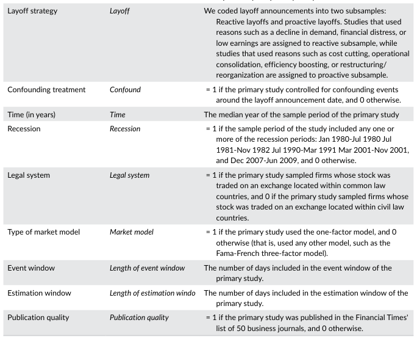

NOTE: complex table shown as an image of the PDF; the text below is a rough machine extraction and may be mis-aligned.

**extracted text (unreliable layout)**

**TA B L E 1** Variable key.

Page 10

ESHGHI and ASTVANSH **10**

### **5 | ANALYSES AND RESULTS**

### **5.1 | Meta-analysis method**

To estimate the average effect of investor reaction to layoff announcements, we recorded the sample size and mean

CAR from every primary study. However, like all meta-analyses, ours is marred by four challenges: (1) publication bias,

(2) missing and incomplete data from primary studies, (3) independence of these studies, and (4) the precision in their

effects. Online Appendix B states how we addressed these challenges.

### **5.2 | Results**

We report the results in two main sections. We test H1, H2a, and H2b <sup>5</sup> by reporting the univariate analysis of the

aggregate effect of layoff announcements on stock return. Next, we use bivariate correlation analysis to test H3 and

H4. Lastly, we present the results of meta-analytic regression analysis (MARA) (the MARA) to test H5a, H5b, and H6.

### 5.2.1 | Univariate analysis

Table 2 reports the results of our univariate analysis for different subsamples. We first tested the significance of the

average value of mean CAR for the entire sample. Overall, on average, investor reaction to layoff announcements is

negative and significant (average of mean CAR = −0.549, *p* < 0.001), supporting our H1. Next, we repeated the anal-

ysis by removing the outliers, which yielded a similar result (average of mean CAR = −0.555, *p* < 0.001). In addition,

the Wilcoxon signed-rank test results show that median values of mean CAR (including and excluding outliers) are

significantly (*p* < 0.05) different from zero. We also tested the magnitude and significance of the average value of

mean CAR for five sub-samples of primary studies based on the length of window (i.e., [−2,2], [−1,0], [−1,1], [0,1],

and [0,0]). The average value for each of the five subsamples is negative and significant (CAR[−2,2] = −0.91, *p* < 0.01;

CAR[−1,0] = −0.65, *p* < 0.01; CAR[0,1] = −0.68, *p* < 0.05; CAR[−1,1] = −0.52, *p* < 0.001; CAR[0,0] = −0.19, *p* < 0.05).

We next tested H2a and H2b by dividing the observations into two subsamples: subsample of layoffs that

signal proactive management and subsample of layoffs that indicate reactive management (proactive layoffs and

reactive layoffs, respectively). The average value of mean CAR for the subsample of proactive layoffs is insignificant

(CAR = 0.134, *n* = 38), indicating that investors do not react to layoff announcements that signal proactive manage-

ment. This finding rejects our H2a. However, the average value of mean CAR for the subsample of reactive layoffs

#### **N studies Sample**

**Mean CAR t-stat Median**

**Std dev Min Max**

**Failsafe N Q-statistic**

CAR 78 126 −0.549 −6.184*** −0.625 0.997 −5.077 2.09 352 646.935***

CAR without

outliers

73 121 −0.555 −6.023*** −0.640 1.014 −5.077 2.09 418 594.858***

Proportion of

negative CARs<sup>a</sup>

23 31 0.170**<sup>b</sup> 0.542***<sup>c</sup> 0.546 0.026 0.360 0.760 305 56.629**

<sup>a</sup>We discuss this effect size (i.e., the proportion of negative CARs) in the robustness checks section.

<sup>b</sup>This is the average effect size before transformation (logit).

<sup>c</sup>This is the average transformed back logit (proportion).

****p* < 0.01, ***p* < 0.05, **p* < 0.1.

**TA B L E 2** Investor reaction to layoff announcement (random-effect meta-analysis).

Page 11

ESHGHI and ASTVANSH **11**

is negative and significant (CAR = −1.399, *p <* 0.001, *n* = 36), indicating that investors penalize firms whose layoff

announcements signal reactive management. This result thus supports our H2b.

### 5.2.2 | Interrelationship analysis (firm size and cumulative abnormal stock return)

We conducted a bivariate correlation analysis (1) between mean CAR from layoff announcements and layoff size (for

H3) and (2) between this mean CAR and firm size (for H4). Table B1 (Online Appendix B) reports the results of the

interrelationship analysis. The correlation between CAR and layoff size based on 17 studies (19 samples and 5065

announcements) is significantly negative (effect size = −0.056, *p <* 0.01). This result supports our H3, suggesting that

as the layoff size increases, investor penalty becomes larger. Based on 18 studies (22 samples and 5353 announce-

ments), the correlation between CAR and firm size is insignificant, rejecting our H4.

### 5.2.3 | Meta-Analytic Regression Analysis

Next, we use a MARA—a weighted least squares regression (Lipsey & Wilson, 2001)—to test H5a, H5b, and H6. We

regress the mean CAR from the primary study on the sample period and the country of the stock exchanges. We

control for (1) whether the primary study excluded layoff announcements that are confounded with other concurrent

news about the same firm (variable name: *Confound*), (2) whether the sample period included any one or more of the

recession periods (see Table 1 for time periods) (*Recession*), (3) whether the primary study used a three/four-factor

market model or its simplest one-factor counterpart (*Market model*), (4) whether the primary study was published in a

Financial Times journal (*Publication quality*), (5) the length of the estimation window (*Length of estimation*), and (6) the

length of the event window (*Length of event window*).

Table 3 reports the MARA results. Models 1 and 2 use the full sample and the sample without outliers, respectively.

Because not all studies explicitly reported the market model and the estimation window they used, these two models

do not include the control variables of the market model and the length of the estimation window. Models 3 and 4

also use the full sample and the sample without outliers, respectively. However, these two models include the market

model and the length of the estimation window used by the primary studies. A negative (positive) coefficient indicates

that the corresponding variable strengthens (weakens) the stock investors' negative reaction to a layoff announcement.

The coefficients for the *Time* variable are positive and significant in all models, indicating that, over time, investors

The coefficients for *Legal system* are positive and marginally significant in all models, indicating that investors are

more punitive toward firms that are traded on exchanges located within civil law systems relative to firms that are

traded on stock exchanges located in common law countries. The results thus support H6.

### **6 | ROBUSTNESS CHECKS**

We test the robustness of our results to (1) alternate method of univariate meta-analysis, (2) test of layoff type

(H2a and H2b), (3) alternate measure of investor reaction, and (4) type of t-statistic. Online Appendix C details the

tests.

Page 12

ESHGHI and ASTVANSH **12**

### **7 | DISCUSSION**

This manuscript measures the investor reaction to corporate announcements of employee layoffs and examines vari-

ation in the reaction based on characteristics suggested by signaling theory. We report six findings. First, on average,

investors punish the layoff-announcing firm. Second, the penalty exists for reactive layoffs and not for proactive

layoffs. Third, the more the number of employees laid off (i.e., layoff size), the more punitive the investors. Fourth,

size of the layoff-announcing firm does not influence investors' reaction. Fifth, investors have become less punitive

over the years. Sixth, firms in common law countries receive lower penalty than firms in civil law countries. We next

discuss the implications of these findings for theory and practice.

### **7.1 | Implications for theory**

Our research makes two theoretical contributions.

First, academics from varied disciplines have used signaling theory to explain firm actions that provide infor-

mation to the firm's stakeholders and thus mitigate information asymmetry between the two parties. However, this

**(1) (2) (3) (4)**

#### **CAR (t-value and *p*-value)**

#### **CAR (t-value and *p*-value)**

#### **CAR (t-value and *p*-value)**

#### **CAR (t-value and *p*-value)**

Time (H5a) 0.03 (2.89 0.005) 0.04 (3.01 0.003) 0.04 (2.76 0.007) 0.03 (2.39 0.019)

[0.01] [0.01] [0.01] [0.02]

[output not shown]

NOTE: table converted from PDF layout to HTML text; cell boundaries are reconstructed. See PDF if exact alignment matters.

*Note*: *Standard errors are in brackets*.

<sup>a</sup>Five studies have samples from multiple countries (e.g., Europe or Global). **We were not able to code these studies based on the legal system**. So, we have 121 samples instead of 126.

**TA B L E 3** Meta-analytic regression analysis (MARA) results.

Page 13

ESHGHI and ASTVANSH **13**

usage has focused on firm actions that communicate *unambiguously positive* information (e.g., product quality) to

its stakeholders. As Connelly et al.’s (2011) review of the signaling theory highlighted, there lies an opportunity

to contribute to signaling theory by applying it to a firm's “negative actions”—such as announcement of employee

layoffs. We leverage this opportunity. First, we reason that because a layoff is costly to the firm, it *is* the firm's signal

to its stakeholders. Importantly, because a layoff is likely to impede a firm's performance in the short-term, the signal

is *negative* in valence. In examining a firm's negative (as opposed to positive) signal, we contribute to the signaling

theory. In addition, in hypothesizing and empirically demonstrating heterogeneity in signal-receiver's reaction based

on characteristics of the signal, signaler, and signaling environment, we provide a complete (as opposed to piecemeal)

application of signaling theory. Such holistic application allows us to reconcile the mixed results from prior primary

studies on investor reactions to layoff announcements.

Second, managers likely know that the layoff announcement will elicit a penalty from investors. Anticipating this

penalty, managers may use impression management tactics to frame their layoff to suppress the penalty. Primed by

this intuition, we integrate the signaling theory with anticipatory impression management theory to theorize that

whereas a reactive layoff would elicit the penalty, its proactive counterpart may not receive the punitive reaction, and

perhaps even earn a reward from investors. Our empirical finding supports this theory. That is, on average, reactive

layoffs receive a penalty, whereas proactively framed announcements receive no reaction.

### **7.2 | Implications for practice**

We organize the implications of our research in a question-and-answer format.

1. *On average, do stock investors reward or penalize a firm for announcing layoffs?* Penalize! The finding helps HRM

managers and officers of a firm know that, on average, investors will penalize the firm for laying off employees.

This finding becomes particularly timely as the economics in most countries are anticipating recession and tech-

nology firms are laying off employees.

2. *How can a firm mitigate or prevent the punitive reaction?* A firm can nullify investor penalty by framing the layoff

announcement to indicate its *proactive* management of its internal problems or external environmental challenges.

Equally—if not more importantly—the firm's announcement should *not* indicate reactive management of its problems

and challenges. For example, on 9 November 2022, Meta Platforms, Inc. announced laying off about 13% or 11,000

employees to “become a leaner and more efficient company” (Meta Platforms Inc, 2022). On 14 March 2023, Meta

announced a layoff of another 10,000 employees, framing the layoff as a means to make the firm more efficient (Meta

Platforms Inc, 2023). The two announcements caused Meta's stock price to climb by 5% (Capoot, 2022) and 1%

(Bushard, 2023), respectively, indicating that investors rewarded efficiency-driven, or proactive layoffs. Our research

informs layoff-announcing firms that reactive layoffs evoke a penalty, whereas proactively framed announcements

elicit no reaction from stock investors. Managers can use our findings to know how to position their layoffs.

3. *Has investor penalty to layoffs increased or decreased over time?* Decreased! We attribute this decrease to layoff

becoming less surprising and investors factoring them into their expectations. Consistent with our finding, recent

primary studies in our sample have documented an insignificant (Bassanini et al., 2020) or positive investor reaction

to layoff announcements (Floros et al., 2021). However, we caution managers that event studies measure investors'

immediate-term reaction to an event. Although investors may have become less punitive to layoff announcements

over time, our evidence does not speak to their longer-term reaction, which may be punitive or rewarding.

4. *Who is less punitive: investors in common-law countries or those in civil-law countries?* Those in common-law coun-

tries, such as the United States. We reason that common-law countries (vs. civil-law countries) have more matured

financial markets and stronger employer rights. Consequently, investors in common-law countries are better

informed than those in civil-law countries and thus the former have less reason to react more sharply, whereas

the latter have reason to estimate the worst-case scenario and thus tend to react more punitively.

Page 14

ESHGHI and ASTVANSH **14**

5. *Does a large layoff hurt more than a smaller layoff?* Yes! Managers may reason that investors react to the *occurrence*

of a layoff announcement rather than the size of the layoff. We correct such misconception by showing that

investors consider the number of laid off employees to estimate the damage to cash flow. Also, investors may

penalize a large layoff disproportionately because it may indicate that managers accumulated the negative news.

If managers believe that layoff is a solution to the firm's problems, they must not let the problems pile up and

announce a large layoff. Instead, they should proactively engage in smaller layoffs.

6. *Do large firms receive less or more penalty relative to their smaller counterparts?* Neither! Because larger firms have

greater slack resources to absorb a short-term shock, such as the severance payments to laid-off employees, one

would expect investors to react less punitively to layoffs by larger firms. However, the counterargument holds as

well. Larger firms receive greater media attention, particularly on negative actions that are relevant to the society.

Therefore, higher volume and more negative coverage from media may cause investors to react more punitively

toward larger firms. Because the empirical evidence suggests no difference in investor reaction for large firms and

small firms, we conjecture that the two theoretical reasons cancel out. Managers of large layoff-announcing firms

should not assume that their firms' size would mitigate investor penalty.

### **7.3 | Limitations**

Our study is limited in at least four ways, each of which merits further research.

First, we focus on stock investors' reaction to layoff announcements. Future research can consider how a firm's layoffs

impact responses from its other stakeholders, such as consumers, suppliers, rivals, top managers, and financial analysts.

Such consideration would enrich theory because investors and these other stakeholders have different—potentially,

competing or conflicting—interests (Li & Wu, 2020). Firm actions that receive a reward from shareholders may evoke a

penalty from other stakeholders because these stakeholder groups diverge on their interests. The context of layoff makes

the conflict-of-interest between shareholders and other stakeholders acute and can help develop and test the theory.

Second, insufficient number of primary studies prevented us from measuring the relationship between the inves-

tor reaction to layoff announcements and firm-level variables such as prior performance and financial leverage. As the

layoff literature accumulates more empirical studies, a future meta-analysis can consider addressing this shortcoming

in our research.

Third, insufficient number of primary studies (only five studies) prevented us from examining whether a firm's layoff

announcement elicits a favorable reaction or an unfavorable reaction from its rivals' investors. Madura et al. (1995) found

a positive reaction, supporting the competition (as opposed to contagion) effect. In contrast, Goins and Gruca (2008)

showed a contagion effect. A future meta-analysis could identify conditions under which these two opposite effects exist.

Fourth, few event studies investigate the long-term impact of layoff announcements, measured by the

Buy-and-Hold Abnormal Returns (BHARs) or Calendar-Time Portfolios Abnormal Returns (Mace, 2020; Scott

et al., 2011). Scott et al. (2011) found that investor reaction in the long term is negative, whereas Mace (2020)

showed that layoffs result in higher returns after 3 years. These inconsistent findings call for future investigation into

the long-term impact of layoff announcements on stock return.

In summary, we believe our meta-analysis offers useful insights for theory and practice, while providing avenues

for future research.

#### **ACKNOWLEDGMENTS**

Not applicable.

#### **CONFLICT OF INTEREST STATEMENT**

The authors declare that they have no conflict of interest.

Page 15

ESHGHI and ASTVANSH **15**

#### **DATA AVAILABILITY STATEMENT**

The data that support the findings of this study are openly available in EBSCO at https://libraries.indiana.edu/.

#### **ENDNOTES**

1 “Quality refers to the underlying, unobservable ability of the signaler to fulfill the needs or demands of an outsider observ-

ing the signal” (Connelly et al., 2011, p. 43).

2 https://www.bls.gov/news.release/union2.nr0.htm

3 https://www.vox.com/policy-and-politics/2017/4/17/15290674/union-labor-movement-europe-bargaining-fight-15-ghent

4 Some studies have more than one sample. Please see Online Appendix (Table D1) for the list of included studies.

5 We also tested H2a and H2b using meta-analytic regression in the robustness check with smaller sample size.

#### **REFERENCES**

Abowd, J. M., Milkovich, G. T., & Hannon, J. M. (1990). The effects of human resource management decisions on shareholder

value. *ILR Review*, *43*(3), 203–236-S. https://doi.org/10.1177/001979399004300313 Astvansh, V., & Eshghi, K. (2023). The effects of regulatory investigation, supplier defect, and product age on stock investors’

reaction to an automobile recall. *Journal of Business Research*, *167*, 114052. Forthcoming. https://doi.org/10.1016/j. jbusres.2023.114052 Atanassov, J., & Kim, E. H. (2009). Labor and corporate governance: International evidence from restructuring decisions. *The*

*Journal of Finance*, *64*(1), 341–374. https://doi.org/10.1111/j.1540-6261.2008.01436.x Banker, R. D., Byzalov, D., & Chen, L. T. (2013). Employment protection legislation, adjustment costs and cross-country

differences in cost behavior. *Journal of Accounting and Economics*, *55*(1), 111–127. https://doi.org/10.1016/j. jacceco.2012.08.003 Bassanini, A., Caroli, E., Ferreira, B. C., & Reberioux, A. (2020). *Don’t downsize this! Social reactions to mass dismissals on Twitter*

(pp. 2–44). IZA Discussion Papers. 13840. Bhana, N. (2002). Layoff announcements, share price reaction and long-term financial performance on the JSE Securities

Exchange. *Investment Analysts Journal*, *31*(56), 41–56. https://doi.org/10.1080/10293523.2002.11082441 Bichescu, B., & Raturi, A. (2015). The antecedents and consequences of plant closing announcements. *International Journal of*

*Production Economics*, *168*, 197–210. https://doi.org/10.1016/j.ijpe.2015.06.029 Blackwell, D. W., Marr, M. W., & Spivey, M. F. (1990). Plant-closing decisions and the market value of the firm. *Journal of*

*Financial Economics*, *26*(2), 277–288. https://doi.org/10.1016/0304-405x(90)90006-l Blanchard, O. J. (1981). Output, the stock market, and interest rates. *The American Economic Review*, *71*(1), 132–143. Boyd, D. E., Sese, F. J., & Tillmanns, S. (2023). The design of B2B customer references: A signaling theory perspective. *Journal*

*of the Academy of Marketing Science*, *51*(3), 658–674. https://doi.org/10.1007/s11747-022-00902-6 Boyd, J. H., Hu, J., & Jagannathan, R. (2005). The stock market's reaction to unemployment news: Why bad news is usually

good for stocks. *The Journal of Finance*, *60*(2), 649–672. https://doi.org/10.1111/j.1540-6261.2005.00742.x Brauer, M., & Laamanen, T. (2014). Workforce downsizing and firm performance: An organizational routine perspective.

*Journal of Management Studies*, *51*(8), 1311–1333. https://doi.org/10.1111/joms.12074 Brauer, M., & Zimmermann, M. (2019). Investor response to workforce downsizing: The influence of industry

waves, macroeconomic outlook, and firm performance. *Journal of Management*, *45*(5), 1775–1801. https://doi. org/10.1177/0149206317734901 Brookman, J. T., Chang, S., & Rennie, C. G. (2007). CEO cash and stock-based compensation changes, layoff decisions, and

shareholder value. *Financial Review*, *42*(1), 99–119. https://doi.org/10.1111/j.1540-6288.2007.00163.x Bushard, B. (2023). Meta stock climbs after reports of more layoffs–Here’s why. Retrieved from https://www.forbes.com/

sites/brianbushard/2023/03/07/meta-stock-climbs-after-reports-of-more-layoffsheres-why/ Cagle, J. A., Sen, A., & Pawlukiewicz, J. E. (2009). Inter-industry differences in layoff announcement effects for financial insti-

tutions. *Journal of Economics and Finance*, *33*(1), 100–110. https://doi.org/10.1007/s12197-008-9062-2 Capoot, A. (2022). Meta shares pop 5% as Wall Street rallies around layoffs. Retrieved from https://www.cnbc.

com/2022/11/09/meta-stock-up-as-wall-street-rallies-around-layoffs.html Cascio, W. F. (1993). Downsizing: What do we know? What have we learned? *Academy of Management Perspectives*, *7*(1),

95–104. https://doi.org/10.5465/ame.1993.9409142062 Chadwick, C., Hunter, L. W., & Walston, S. L. (2004). Effects of downsizing practices on the performance of hospitals. *Strategic*

*Management Journal*, *25*(5), 405–427. https://doi.org/10.1002/smj.383 Chalos, P., & Chen, C. J. (2002). Employee downsizing strategies: Market reaction and post announcement financial perfor-

mance. *Journal of Business Finance & Accounting*, *29*(5-6), 847–870. https://doi.org/10.1111/1468-5957.00453 Chatrath, A., Ramchander, S., & Song, F. (1995). Are market perceptions of corporate layoffs changing? *Economics Letters*,

*47*(3–4), 335–342. https://doi.org/10.1016/0165-1765(94)00543-b

Page 16

ESHGHI and ASTVANSH **16**

Chen, P., Mehrotra, V., Sivakumar, R., & Wayne, W. Y. (2001). Layoffs, shareholders' wealth, and corporate performance.

*Journal of Empirical Finance*, *8*(2), 171–199. https://doi.org/10.1016/s0927-5398(01)00024-x Chokshi, N., & Metz, C. (2022). Tesla to cut 10% of salaried staff, Musk tells employees. Retrieved from https://www.nytimes.

com/2022/06/03/business/tesla-elon-musk-job-cuts.html Collett, N. (2002). Reactions of the international stock exchange to company employment announcements: Redundancies and

new jobs. *Journal of Business Finance & Accounting*, *29*(9-10), 1181–1208. https://doi.org/10.1111/1468-5957.00466 Connelly, B. L., Certo, S. T., Ireland, R. D., & Reutzel, C. R. (2011). Signaling theory: A review and assessment. *Journal of*

*Management*, *37*(1), 39–67. https://doi.org/10.1177/0149206310388419 Datta, D. K., Guthrie, J. P., Basuil, D., & Pandey, A. (2010). Causes and effects of employee downsizing: A review and synthesis.

*Journal of Management*, *36*(1), 281–348. https://doi.org/10.1177/0149206309346735 Deephouse, D. L. (2000). Media reputation as a strategic resource: An integration of mass communication and resource-based

theories. *Journal of Management*, *26*(6), 1091–1112. https://doi.org/10.1177/014920630002600602 Duran, P., Kammerlander, N., Van Essen, M., & Zellweger, T. (2016). Doing more with less: Innovation input and output in

family firms. *Academy of Management Journal*, *59*(4), 1224–1264. https://doi.org/10.5465/amj.2014.0424 Elayan, F. A., Swales, G. S., Maris, B. A., & Scott, J. R. (1998). Market reactions, characteristics, and the effectiveness of corpo-

rate layoffs. *Journal of Business Finance & Accounting*, *25*(3-4), 329–351. https://doi.org/10.1111/1468-5957.00190 Erdem, T., Keane, M. P., & Sun, B. (2008). A dynamic model of brand choice when price and advertising signal product quality.

*Marketing Science*, *27*(6), 1111–1125. https://doi.org/10.1287/mksc.1080.0362 Fama, E. F., & French, K. R. (1992). The cross-section of expected stock returns. *The Journal of Finance*, *47*(2), 427–465.

https://doi.org/10.1111/j.1540-6261.1992.tb04398.x Farber, H. S., & Hallock, K. (1999). *Have employment reductions become good news for shareholders? The effect of job loss*

*announcements on stock prices* (Vols. 1970–97). National Bureau of Economic Research, Inc. No. 7295. Farber, H. S., & Hallock, K. F. (2009). The changing relationship between job loss announcements and stock prices: 1970–

1999. *Labour Economics*, *16*(1), 1–11. https://doi.org/10.1016/j.labeco.2008.04.002 Filbeck, G., & Webb, S. E. (2001). Information asymmetries, managerial ownership, and the impact of layoff announcements

on shareholder wealth. *Quarterly Journal of Business & Economics*, 31–47. Flanagan, D. J., & O’Shaughnessy, K. C. (2005). The effect of layoffs on firm reputation. *Journal of Management*, *31*(3),

445–463. https://doi.org/10.1177/0149206304272186 Floros, C., Psillaki, M., & Karpouzis, E. (2021). Layoffs and stock market performance during the COVID-19 pandemic:

Evidence from the US. *Journal of Economic Studies*, *2*(50), 96–108. https://doi.org/10.1108/jes-05-2021-0224 Garavan, T., McCarthy, A., Lai, Y., Murphy, K., Sheehan, M., & Carbery, R. (2021). Training and organisational performance: A

meta-analysis of temporal, institutional and organisational context moderators. *Human Resource Management Journal*, *31*(1), 93–119. https://doi.org/10.1111/1748-8583.12284 Geoffrey Love, E., & Nohria, N. (2005). Reducing slack: The performance consequences of downsizing by large industrial

firms, 1977–93. *Strategic Management Journal*, *26*(12), 1087–1108. https://doi.org/10.1002/smj.487 Gerlach, R., Chen, C. W., Lin, D. S., & Huang, M. H. (2006). Asymmetric responses of international stock markets to

trading volume. *Physica A: Statistical Mechanics and its Applications*, *360*(2), 422–444. https://doi.org/10.1016/j. physa.2005.06.045 Goergen, M., Brewster, C., & Wood, G. (2013). The effects of the national setting on employment practice: The case of down-

sizing. *International Business Review*, *22*(6), 1051–1067. https://doi.org/10.1016/j.ibusrev.2013.02.001 Goins, S., & Gruca, T. S. (2008). Understanding competitive and contagion effects of layoff announcements. *Corporate Repu-*

*tation Review*, *11*(1), 12–34. https://doi.org/10.1057/crr.2008.3 Graffin, S. D., Haleblian, J., & Kiley, J. T. (2016). Ready, AIM, acquire: Impression offsetting and acquisitions. *Academy of*

*Management Journal*, *59*(1), 232–252. https://doi.org/10.5465/amj.2013.0288 Groening, C., Mittal, V., & Anthea Zhang, Y. (2016). Cross-validation of customer and employee signals and firm valuation.

*Journal of Marketing Research*, *53*(1), 61–76. https://doi.org/10.1509/jmr.12.0272 Gunderson, M., Verma, A., & Verma, S. (1997). Impact of layoff announcements on the market value of the firm. *Relations*

*Industrielles/Industrial Relations*, *52*(2), 364–381. https://doi.org/10.7202/051170ar Harney, B., Fu, N., & Freeney, Y. (2018). Balancing tensions: Buffering the impact of organisational restructur-

ing and downsizing on employee well-being. *Human Resource Management Journal*, *28*(2), 235–254. https://doi. org/10.1111/1748-8583.12175 Hendricks, K. B., & Singhal, V. R. (2005). An empirical analysis of the effect of supply chain disruptions on long-run stock

price performance and equity risk of the firm. *Production and Operations Management*, *14*(1), 35–52. https://doi. org/10.1111/j.1937-5956.2005.tb00008.x Hillier, D., Marshall, A., McColgan, P., & Werema, S. (2007). Employee layoffs, shareholder wealth and firm perfor-

mance: Evidence from the UK. *Journal of Business Finance & Accounting*, *34*(3-4), 467–494. https://doi. org/10.1111/j.1468-5957.2007.02042.x

Page 17

ESHGHI and ASTVANSH **17**

Hunter, J. E., & Schmidt, F. L. (1991). Meta-analysis. In *Advances in educational and psychological testing: Theory and applica-*

*tions* (pp. 157–183). Springer. Iqbal, Z., & Shetty, S. (1995). Layoffs, stock price, and financial condition of the firm. *Journal of Applied Business Research*,

*11*(2), 67. https://doi.org/10.19030/jabr.v11i2.5876 Jensen, M. C., & Meckling, W. H. (1976). Theory of the firm: Managerial behavior, agency costs and ownership structure.

*Journal of Financial Economics*, *3*(4), 305–360. https://doi.org/10.1016/0304-405x(76)90026-x Johnstone, S. (2023). Human resource management in recession: Restructuring and alternatives to downsizing in times of

crisis. *Human Resource Management Journal*. forthcoming. https://doi.org/10.1111/1748-8583.12512 Karim, K. E., Rutledge, R. W., Gara, S. C., & Ahmed, M. U. (2001). An empirical examination of the pricing of seasoned equity

offerings: A test of the signaling hypothesis. *Review of Quantitative Finance and Accounting*, *17*(1), 63–79. https://doi. org/10.1023/a:1011257504873 Kelley, L., & Yaffe-Bellany, D. (2022). Robinhood lays off 23% of its staff, blaming crypto meltdown and inflation. Retrieved

from https://www.nytimes.com/2022/08/02/business/robinhood-layoffs.html Kirmani, A., & Rao, A. R. (2000). No pain, no gain: A critical review of the literature on signaling unobservable product quality.

*Journal of Marketing*, *64*(2), 66–79. https://doi.org/10.1509/jmkg.64.2.66.18000 Krantz, M. (2022). Investors pay the price when bloated companies lay off workers. Retrieved from https://www.investors.

com/etfs-and-funds/sectors/sp500-companies-dumping-employees-are-already-paying-the-price/ Krishnan, H. A., Hitt, M. A., & Park, D. (2007). Acquisition premiums, subsequent workforce reductions and post-acquisition

performance. *Journal of Management Studies*, *44*(5), 709–732. https://doi.org/10.1111/j.1467-6486.2006.00672.x Kunert, S., Schiereck, D., & Welkoborsky, C. (2017). Stock market reactions to layoff announcements–analysis of the renew-

able energy sector. *International Journal of Energy Sector Management*, *2*(11), 311–328. https://doi.org/10.1108/ ijesm-02-2016-0004 Lacker, J. M., & Weinberg, J. A. (1989). Optimal contracts under costly state falsification. *Journal of Political Economy*, *97*(6),

1345–1363. https://doi.org/10.1086/261657 Landsman, V., & Stremersch, S. (2020). The commercial consequences of collective layoffs: Close the plant, lose the brand?

*Journal of Marketing*, *84*(3), 122–141. https://doi.org/10.1177/0022242919901277 La Porta, R., Lopez-de-Silanes, F., Shleifer, A., & Vishny, R. (1999). The quality of government. *Journal of Law, Economics, and*

*Organization*, *15*(1), 222–279. https://doi.org/10.1093/jleo/15.1.222 La Porta, R., Lopez-de-Silanes, F., Shleifer, A., & Vishny, R. (2000). Investor protection and corporate governance. *Journal of*

*Financial Economics*, *58*(1–2), 3–27. https://doi.org/10.1016/s0304-405x(00)00065-9 Lee, P. M. (1997). A comparative analysis of layoff announcements and stock price reactions in the

United States and Japan. *Strategic Management Journal*, *18*(11), 879–894. https://doi.org/10.1002/ (sici)1097-0266(199712)18:11<879::aid-smj929>3.0.co;2-v Lewin, J. E. (2009). Business customers' satisfaction: What happens when suppliers downsize? *Industrial Marketing Manage-*

*ment*, *38*(3), 283–299. https://doi.org/10.1016/j.indmarman.2007.11.005 Li, J., & Wu, D. (2020). Do corporate social responsibility engagements lead to real environmental, social, and governance

impact? *Management Science*, *66*(6), 2564–2588. https://doi.org/10.1287/mnsc.2019.3324 Lin, J. C., & Rozeff, M. S. (1993). Capital market behavior and operational announcements of layoffs, operation closings, and

pay cuts. *Review of Quantitative Finance and Accounting*, *3*(1), 29–45. https://doi.org/10.1007/bf02408411 Lipsey, M. W., & Wilson, D. B. (2001). *Practical meta-analysis*. SAGE publications, Inc. Mace, C. (2020). The Market loves a layoff. Retrieved from https://papers.ssrn.com/sol3/papers.cfm?abstract_id=3713347 Madura, J., Akhigbe, A., & Bartunek, K. S. (1995). Intra-industry effects of bank layoff announcements. *Review of Financial*

*Economics*, *4*(2), 187–195. https://doi.org/10.1016/1058-3300(95)90006-3 Marshall, A., McColgan, P., & McLeish, S. (2012). Why do stock prices decline in response to employee layoffs?

UK evidence from the 2008 global financial crisis. *Journal of Financial Research*, *35*(3), 375–396. https://doi. org/10.1111/j.1475-6803.2012.01321.x McCabe, C. (2022). Robinhood shares surge after layoffs announcement. Retrieved from https://www.wsj.com/livecov-

erage/stock-market-news-today-08-03-2022/card/robinhood-shares-surge-after-layoffs-announcement-Vx4NFcEK93ZH3rPu9lTO McCombs, M. E., & Shaw, D. L. (1972). The agenda-setting function of mass media. *Public Opinion Quarterly*, *36*(2), 176–187.

https://doi.org/10.1086/267990 McKnight, P. J., Lowrie, A., & Coles, C. (2002). Investor reactions, social implications and layoff announcements

in the UK: A comparison between periods. *Journal of Management & Governance*, *6*(1), 83–100. https://doi. org/10.1023/a:1015563926170 Meta Platforms, Inc. (2022). Mark Zuckerberg’s message to Meta employees. Retrieved from https://about.fb.com/

news/2022/11/mark-zuckerberg-layoff-message-to-employees/ Meta Platforms, Inc. (2023). Mark Zuckerberg’s facebook post. Retrieved from https://www.facebook.com/story.

php?story_fbid=pfbid0382gobPjUPCEGVWwrJJvuNCEhoZHgxT1q9mm3BMm9hMYKKqSxj2zaqaPeYBw3GFFel&id=4

Page 18

ESHGHI and ASTVANSH **18**

Moy, J., & Sorrentino, C. (1981). Unemployment, labor force trends, and layoff practices in 10 countries. *Monthly Labor*

*Review*, *104*, 3. Nixon, R. D., Hitt, M. A., Lee, H. U., & Jeong, E. (2004). Market reactions to announcements of corporate downsizing actions

and implementation strategies. *Strategic Management Journal*, *25*(11), 1121–1129. https://doi.org/10.1002/smj.423 Nzau, K. J. (2016). *The effects of employee layoffs announcements on stock returns of firms listed at the Nairobi securities exchange,*

*Master thesis*. University of Nairobi. Retrieved from http://erepository.uonbi.ac.ke:8080/handle/11295/97672 O'Boyle, E. H., Patel, P. C., & Gonzalez-Mulé, E. (2016). Employee ownership and firm performance: A meta-analysis. *Human*

*Resource Management Journal*, *26*(4), 425–448. https://doi.org/10.1111/1748-8583.12115 Palmon, O., Sun, H. L., & Tang, A. P. (1997). Layoff announcements: Stock market impact and financial performance. *Financial*

*Management*, *26*(3), 54–69. https://doi.org/10.2307/3666213 Paulsen, N., Callan, V. J., Grice, T. A., Rooney, D., Gallois, C., Jones, E., Jimmieson, N. L., & Bordia, P. (2005). Job uncertainty and

personal control during downsizing: A comparison of survivors and victims. *Human Relations*, *58*(4), 463–496. https:// doi.org/10.1177/0018726705055033 Post, C., & Byron, K. (2015). Women on boards and firm financial performance: A meta-analysis. *Academy of Management*

*Journal*, *58*(5), 1546–1571. https://doi.org/10.5465/amj.2013.0319 Saboo, A. R., & Grewal, R. (2013). Stock market reactions to customer and competitor orientations: The case of initial public

offerings. *Marketing Science*, *32*(1), 70–88. https://doi.org/10.1287/mksc.1120.0749 Schulz, A. C., & Himme, A. (2022). Stock market reactions to downsizing announcements: An analysis through an institutional

lens. *Socio-Economic Review*, *20*(4), 1825–1855. https://doi.org/10.1093/ser/mwab046 Schweizer, L., & Bilsdorfer, P. T. (2016). Stock price reactions to corporate layoff announcements: A resource and systems

theory-based analysis of socially accepted layoff procedures. *Corporate Responsibility: Social Action, Institutions and Governance*, *95*. Scott, B. G., Ueng, J., Ramaswamy, V., & Chang, C. L. (2011). Layoff and firm long-term performance. *Academy of Strategic*

*Management Journal*, *10*(2), 1. Snikersproge, I. (2023). Stock market layoffs in France: How finance knows when to fire industrial workers. *American Ethnol-*

*ogist*, *50*(2), 297–308. https://doi.org/10.1111/amet.13167 Spence, M. (1973). Job market signaling. *Quarterly Journal of Economics*, *87*(3), 355–374. https://doi.org/10.2307/1882010 Spivey, M. F., Blackwell, D. W., & Marr, M. W. (1994). Advance notice of plant closings and firm value. *Journal of Business*

*Research*, *31*(1), 49–53. https://doi.org/10.1016/0148-2963(94)90045-0 Stocken, P. C. (2000). Credibility of voluntary disclosure. *The RAND Journal of Economics*, *31*(2), 359. https://doi.

org/10.2307/2601045 Ursel, N., & Armstrong-Stassen, M. (1995). The impact of layoff announcements on shareholders. *Relations Industrielles/*

*Industrial Relations*, *50*(3), 636–649. https://doi.org/10.7202/051038ar Van Dierendonck, D., & Jacobs, G. (2012). Survivors and victims, a meta-analytical review of fairness and organizational

commitment after downsizing. *British Journal of Management*, *23*(1), 96–109. Velásquez, S., Kanniainen, J., Mäkinen, S., & Valli, J. (2018). Layoff announcements and intra-day market reactions. *Review of*

*Managerial Science*, *12*(1), 203–228. https://doi.org/10.1007/s11846-016-0219-7 Von Mehren, A. T. (1997). Some reflections on codification and case law in the twenty-first century. *UC Davis Law Review*,

*31*, 659. Wernerfelt, B. (1984). A resource-based view of the firm. *Strategic Management Journal*, *5*(2), 171–180. https://doi.

org/10.1002/smj.4250050207 Worrell, D. L., Davidson, W. N., III, & Sharma, V. M. (1991). Layoff announcements and stockholder wealth. *Academy of*

*Management Journal*, *34*(3), 662–678. https://doi.org/10.5465/256410 Zeitoun, H., & Pamini, P. (2021). A promise made is a promise kept: Union voice, HRM practices, implicit contracts and

workplace performance in times of crisis. *Human Resource Management Journal*, *31*(1), 277–292. https://doi. org/10.1111/1748-8583.12308

#### **SUPPORTING INFORMATION**

Additional supporting information can be found online in the Supporting Information section at the end of this

article.

**How to cite this article:** Eshghi, K., & Astvansh, V. (2023). Stock investors' reaction to layoff

announcements: A meta-analysis. *Human Resource Management Journal*, 1–18. https://doi.

org/10.1111/1748-8583.12532